# 11_exploratory_ensemble_analysis

Yiwen Xiang

This file uses the important-feature model test-set predictions saved by `09_heldout_test_evaluation.Rmd` to evaluate simple ensemble models. It does not retrain models. Instead, it compares single-model performance, prediction correlations, and all three-model majority-voting combinations among the six important-feature models.

The ensemble analysis uses predicted Low_QoL probabilities for the correlation matrix and predicted classes recreated at the default threshold of 0.50 for majority voting.

# 1 1. Setup

# 2 2. Load important-feature model predictions

```r
prediction_file <- file.path(
  processed_path,
  "09_important_model_test_predictions_all6.rds"
)


if (!file.exists(prediction_file)) {
  stop(
    "Cannot find important-feature test predictions. Please run 09_heldout_test_evaluation.Rmd first: ",
    prediction_file
  )
}

selected_model_predictions <- readRDS(prediction_file)
```

```r
required_cols <- c(
  "idauniq",
  "qol_status",
  "model_id",
  "model",
  ".pred_Low_QoL",
  ".pred_Non_low_QoL",
  ".pred_class"
)

missing_cols <- setdiff(required_cols, names(selected_model_predictions))

if (length(missing_cols) > 0) {
  stop(
    "The prediction file is missing required columns: ",
    paste(missing_cols, collapse = ", ")
  )
}
```

```r
selected_model_predictions <- selected_model_predictions %>%
  mutate(
    qol_status = factor(
      as.character(qol_status),
      levels = c("Low_QoL", "Non_low_QoL")
    ),
    .pred_class = factor(
      as.character(.pred_class),
      levels = c("Low_QoL", "Non_low_QoL")
    )
  )

if (anyNA(selected_model_predictions$qol_status)) {
  stop(
    "Unknown or missing outcome labels were found."
  )
}


selected_model_predictions %>%
  count(model)
```

```
## # A tibble: 6 × 2
##   model                                                n
##   <chr>                                            <int>
## 1 Important-feature CatBoost (15)                   1595
## 2 Important-feature LASSO logistic regression (15)  1595
## 3 Important-feature LightGBM (15)                   1595
## 4 Important-feature MLP (15)                        1595
## 5 Important-feature Random Forest (15)              1595
## 6 Important-feature XGBoost (15)                    1595
```

# 3 3. Model registry

```r
expected_model_ids <- c(
  "lasso_logistic_selected",
  "rf_selected",
  "xgb_selected",
  "catboost_selected",
  "lightgbm_selected",
  "mlp_selected"
)

observed_model_ids <- sort(
  unique(selected_model_predictions$model_id)
)

if (!setequal(expected_model_ids, observed_model_ids)) {
  stop(
    paste0(
      "Unexpected model set. Expected: ",
      paste(expected_model_ids, collapse = ", "),
      ". Observed: ",
      paste(observed_model_ids, collapse = ", ")
    )
  )
}

inconsistent_model_labels <- selected_model_predictions %>%
  distinct(model_id, model) %>%
  count(model_id) %>%
  filter(n != 1)

if (nrow(inconsistent_model_labels) > 0) {
  stop(
    "Some model IDs are associated with multiple model labels."
  )
}

duplicate_predictions <- selected_model_predictions %>%
  count(idauniq, model_id) %>%
  filter(n != 1)

if (nrow(duplicate_predictions) > 0) {
  stop(
    "Some participants do not have exactly one prediction per model."
  )
}

incomplete_model_coverage <- selected_model_predictions %>%
  distinct(idauniq, model_id) %>%
  count(idauniq) %>%
  filter(n != length(expected_model_ids))

if (nrow(incomplete_model_coverage) > 0) {
  stop(
    "Some participants do not have predictions from all six models."
  )
}

inconsistent_outcomes <- selected_model_predictions %>%
  distinct(idauniq, qol_status) %>%
  count(idauniq) %>%
  filter(n != 1)

if (nrow(inconsistent_outcomes) > 0) {
  stop(
    "Some participants have inconsistent outcome labels across models."
  )
}

if (
  anyNA(selected_model_predictions$.pred_Low_QoL) ||
  anyNA(selected_model_predictions$.pred_Non_low_QoL)
) {
  stop("Missing predicted probabilities were found.")
}

if (
  any(selected_model_predictions$.pred_Low_QoL < 0) ||
  any(selected_model_predictions$.pred_Low_QoL > 1) ||
  any(selected_model_predictions$.pred_Non_low_QoL < 0) ||
  any(selected_model_predictions$.pred_Non_low_QoL > 1)
) {
  stop("Predicted probabilities outside the range 0 to 1 were found.")
}

if (
  any(
    abs(
      selected_model_predictions$.pred_Low_QoL +
        selected_model_predictions$.pred_Non_low_QoL -
        1
    ) > 1e-6
  )
) {
  stop(
    "The predicted probabilities do not sum to 1."
  )
}

make_short_model_name <- function(model_id) {
  case_when(
    model_id == "lasso_logistic_selected" ~ "LASSO",
    model_id == "rf_selected" ~ "Random Forest",
    model_id == "xgb_selected" ~ "XGBoost",
    model_id == "catboost_selected" ~ "CatBoost",
    model_id == "lightgbm_selected" ~ "LightGBM",
    model_id == "mlp_selected" ~ "MLP",
    TRUE ~ model_id
  )
}

model_registry <- selected_model_predictions %>%
  distinct(model_id, model) %>%
  mutate(
    model_short = make_short_model_name(model_id),
    model_order = match(model_id, expected_model_ids)
  ) %>%
  arrange(model_order) %>%
  select(-model_order)

ensemble_model_ids <- model_registry$model_id

selected_model_predictions <- selected_model_predictions %>%
  left_join(
    model_registry %>% select(model_id, model_short),
    by = "model_id"
  )

model_registry
```

```
## # A tibble: 6 × 3
##   model_id                model                                      model_short
##   <chr>                   <chr>                                      <chr>
## 1 lasso_logistic_selected Important-feature LASSO logistic regressi… LASSO
## 2 rf_selected             Important-feature Random Forest (15)       Random For…
## 3 xgb_selected            Important-feature XGBoost (15)             XGBoost
## 4 catboost_selected       Important-feature CatBoost (15)            CatBoost
## 5 lightgbm_selected       Important-feature LightGBM (15)            LightGBM
## 6 mlp_selected            Important-feature MLP (15)                 MLP
```

# 4 4. Helper function for probability-to-class conversion

```r
default_threshold <- 0.5

make_class_from_probability <- function(probability, threshold = 0.5) {
  factor(
    if_else(probability >= threshold, "Low_QoL", "Non_low_QoL"),
    levels = c("Low_QoL", "Non_low_QoL")
  )
}
```

# 5 5. Helper function for model evaluation

```r
evaluate_predictions <- function(pred_df, result_type, threshold = 0.5) {

  model_id_i <- unique(pred_df$model_id)

  if ("model_short" %in% names(pred_df)) {
    model_i <- unique(pred_df$model_short)
  } else {
    model_i <- unique(pred_df$model)
  }

  if (length(model_id_i) != 1) {
    stop(
      "Each evaluation data frame must contain exactly one model_id."
    )
  }

  if (
    length(model_i) != 1 ||
    anyNA(model_i)
  ) {
    stop(
      "Each evaluation data frame must contain exactly one model label."
    )
  }

  # Recreate classes so all models use the same threshold.
  pred_eval <- pred_df %>%
    mutate(
      qol_status = factor(
        as.character(qol_status),
        levels = c("Low_QoL", "Non_low_QoL")
      ),
      .pred_class = make_class_from_probability(.pred_Low_QoL, threshold)
    )


  bind_rows(
    pred_eval %>%
      roc_auc(truth = qol_status, .pred_Low_QoL, event_level = "first"),

    pred_eval %>%
      pr_auc(truth = qol_status, .pred_Low_QoL, event_level = "first"),

    pred_eval %>%
      accuracy(truth = qol_status, estimate = .pred_class),

    pred_eval %>%
      precision(truth = qol_status, estimate = .pred_class, event_level = "first"),

    pred_eval %>%
      sens(truth = qol_status, estimate = .pred_class, event_level = "first"),

    pred_eval %>%
      spec(truth = qol_status, estimate = .pred_class, event_level = "first"),

    pred_eval %>%
      f_meas(truth = qol_status, estimate = .pred_class, event_level = "first")
  ) %>%
    mutate(
      result_type = result_type,
      model_id = model_id_i,
      model = model_i,
      threshold = threshold
    ) %>%
    select(
      result_type,
      model_id,
      model,
      threshold,
      .metric,
      .estimator,
      .estimate
    )
}
```

# 6 6. Helper function for metric tables

```r
metrics_to_wide <- function(metrics_long) {
  metrics_long %>%
    mutate(
      .metric = case_when(
        .metric == "roc_auc" ~ "ROC_AUC",
        .metric == "pr_auc" ~ "PR_AUC",
        .metric == "accuracy" ~ "Accuracy",
        .metric == "precision" ~ "Precision",
        .metric == "sens" ~ "Sensitivity/Recall",
        .metric == "spec" ~ "Specificity",
        .metric == "f_meas" ~ "F1",
        TRUE ~ .metric
      )
    ) %>%
    select(
      result_type,
      model_id,
      model,
      threshold,
      .metric,
      .estimate
    ) %>%
    pivot_wider(
      names_from = .metric,
      values_from = .estimate
    ) %>%
    select(
      result_type,
      model_id,
      Model = model,
      threshold,
      ROC_AUC,
      PR_AUC,
      Accuracy,
      Precision,
      `Sensitivity/Recall`,
      Specificity,
      F1
    )
}
```

# 7 7. Single-model performance

```r
single_model_results_long <- selected_model_predictions %>%
  split(.$model_id) %>%
  map_dfr(
    ~ evaluate_predictions(
      pred_df = .x,
      result_type = "single_model",
      threshold = default_threshold
    )
  )

single_model_results_wide <- metrics_to_wide(single_model_results_long) %>%
  mutate(model_order = match(model_id, ensemble_model_ids)) %>%
  arrange(model_order) %>%
  select(-model_order)

single_model_results_wide
```

```
## # A tibble: 6 × 11
##   result_type  model_id        Model threshold ROC_AUC PR_AUC Accuracy Precision
##   <chr>        <chr>           <chr>     <dbl>   <dbl>  <dbl>    <dbl>     <dbl>
## 1 single_model lasso_logistic… LASSO       0.5   0.907  0.801    0.865     0.8
## 2 single_model rf_selected     Rand…       0.5   0.903  0.799    0.863     0.789
## 3 single_model xgb_selected    XGBo…       0.5   0.905  0.801    0.867     0.802
## 4 single_model catboost_selec… CatB…       0.5   0.909  0.804    0.865     0.787
## 5 single_model lightgbm_selec… Ligh…       0.5   0.905  0.802    0.865     0.780
## 6 single_model mlp_selected    MLP         0.5   0.893  0.795    0.861     0.765
## # ℹ 3 more variables: `Sensitivity/Recall` <dbl>, Specificity <dbl>, F1 <dbl>
```

# 8 8. Wide prediction tables

```r
probability_wide <- selected_model_predictions %>%
  select(idauniq, qol_status, model_id, .pred_Low_QoL) %>%
  pivot_wider(
    names_from = model_id,
    values_from = .pred_Low_QoL
  )

class_wide <- selected_model_predictions %>%
  mutate(
    .pred_class_vote = make_class_from_probability(
      .pred_Low_QoL,
      threshold = default_threshold
    )
  ) %>%
  select(
    idauniq,
    qol_status,
    model_id,
    .pred_class = .pred_class_vote
  ) %>%
  pivot_wider(
    names_from = model_id,
    values_from = .pred_class
  )

head(probability_wide)
```

```
## # A tibble: 6 × 8
##   idauniq qol_status  lasso_logistic_selected rf_selected xgb_selected
##     <dbl> <fct>                         <dbl>       <dbl>        <dbl>
## 1  104826 Low_QoL                      0.342      0.441         0.379
## 2  104042 Low_QoL                      0.217      0.279         0.240
## 3  107457 Low_QoL                      0.980      0.730         0.852
## 4  108601 Non_low_QoL                  0.281      0.315         0.311
## 5  105751 Non_low_QoL                  0.0419     0.0444        0.0509
## 6  108218 Non_low_QoL                  0.0219     0.00159       0.0226
## # ℹ 3 more variables: catboost_selected <dbl>, lightgbm_selected <dbl>,
## #   mlp_selected <dbl>
```

```r
head(class_wide)
```

```
## # A tibble: 6 × 8
##   idauniq qol_status  lasso_logistic_selected rf_selected xgb_selected
##     <dbl> <fct>       <fct>                   <fct>       <fct>
## 1  104826 Low_QoL     Non_low_QoL             Non_low_QoL Non_low_QoL
## 2  104042 Low_QoL     Non_low_QoL             Non_low_QoL Non_low_QoL
## 3  107457 Low_QoL     Low_QoL                 Low_QoL     Low_QoL
## 4  108601 Non_low_QoL Non_low_QoL             Non_low_QoL Non_low_QoL
## 5  105751 Non_low_QoL Non_low_QoL             Non_low_QoL Non_low_QoL
## 6  108218 Non_low_QoL Non_low_QoL             Non_low_QoL Non_low_QoL
## # ℹ 3 more variables: catboost_selected <fct>, lightgbm_selected <fct>,
## #   mlp_selected <fct>
```

# 9 9. Prediction correlation matrix

```r
prediction_correlation_matrix <- probability_wide %>%
  select(all_of(ensemble_model_ids)) %>%
  cor(
    use = "complete.obs",
    method = "pearson"
  )

correlation_model_names <- setNames(
  model_registry$model_short,
  model_registry$model_id
)

rownames(prediction_correlation_matrix) <- correlation_model_names[
  rownames(prediction_correlation_matrix)
]
colnames(prediction_correlation_matrix) <- correlation_model_names[
  colnames(prediction_correlation_matrix)
]

prediction_correlation_table <- prediction_correlation_matrix %>%
  as.data.frame() %>%
  rownames_to_column("Model")

prediction_correlation_table
```

```
##           Model     LASSO Random Forest   XGBoost  CatBoost  LightGBM       MLP
## 1         LASSO 1.0000000     0.9670376 0.9848539 0.9854979 0.9847407 0.9742741
## 2 Random Forest 0.9670376     1.0000000 0.9824163 0.9752460 0.9760070 0.9533931
## 3       XGBoost 0.9848539     0.9824163 1.0000000 0.9905023 0.9950563 0.9631624
## 4      CatBoost 0.9854979     0.9752460 0.9905023 1.0000000 0.9928981 0.9656587
## 5      LightGBM 0.9847407     0.9760070 0.9950563 0.9928981 1.0000000 0.9637066
## 6           MLP 0.9742741     0.9533931 0.9631624 0.9656587 0.9637066 1.0000000
```

```r
prediction_correlation_long <- prediction_correlation_table %>%
  pivot_longer(
    cols = -Model,
    names_to = "model_2",
    values_to = "correlation"
  ) %>%
  rename(model_1 = Model)

pairwise_correlation_pairs <- prediction_correlation_long %>%
  filter(as.character(model_1) < as.character(model_2)) %>%
  arrange(desc(correlation))

correlation_summary <- pairwise_correlation_pairs %>%
  summarise(
    minimum_correlation = min(correlation),
    maximum_correlation = max(correlation),
    mean_correlation = mean(correlation)
  )

high_correlation_pairs <- pairwise_correlation_pairs %>%
  filter(correlation >= 0.90) %>%
  select(model_1, model_2, correlation)

pairwise_correlation_pairs
```

```
## # A tibble: 15 × 3
##    model_1       model_2       correlation
##    <chr>         <chr>               <dbl>
##  1 LightGBM      XGBoost             0.995
##  2 CatBoost      LightGBM            0.993
##  3 CatBoost      XGBoost             0.991
##  4 CatBoost      LASSO               0.985
##  5 LASSO         XGBoost             0.985
##  6 LASSO         LightGBM            0.985
##  7 Random Forest XGBoost             0.982
##  8 LightGBM      Random Forest       0.976
##  9 CatBoost      Random Forest       0.975
## 10 LASSO         MLP                 0.974
## 11 LASSO         Random Forest       0.967
## 12 CatBoost      MLP                 0.966
## 13 LightGBM      MLP                 0.964
## 14 MLP           XGBoost             0.963
## 15 MLP           Random Forest       0.953
```

```r
correlation_summary
```

```
## # A tibble: 1 × 3
##   minimum_correlation maximum_correlation mean_correlation
##                 <dbl>               <dbl>            <dbl>
## 1               0.953               0.995            0.977
```

```r
high_correlation_pairs
```

```
## # A tibble: 15 × 3
##    model_1       model_2       correlation
##    <chr>         <chr>               <dbl>
##  1 LightGBM      XGBoost             0.995
##  2 CatBoost      LightGBM            0.993
##  3 CatBoost      XGBoost             0.991
##  4 CatBoost      LASSO               0.985
##  5 LASSO         XGBoost             0.985
##  6 LASSO         LightGBM            0.985
##  7 Random Forest XGBoost             0.982
##  8 LightGBM      Random Forest       0.976
##  9 CatBoost      Random Forest       0.975
## 10 LASSO         MLP                 0.974
## 11 LASSO         Random Forest       0.967
## 12 CatBoost      MLP                 0.966
## 13 LightGBM      MLP                 0.964
## 14 MLP           XGBoost             0.963
## 15 MLP           Random Forest       0.953
```

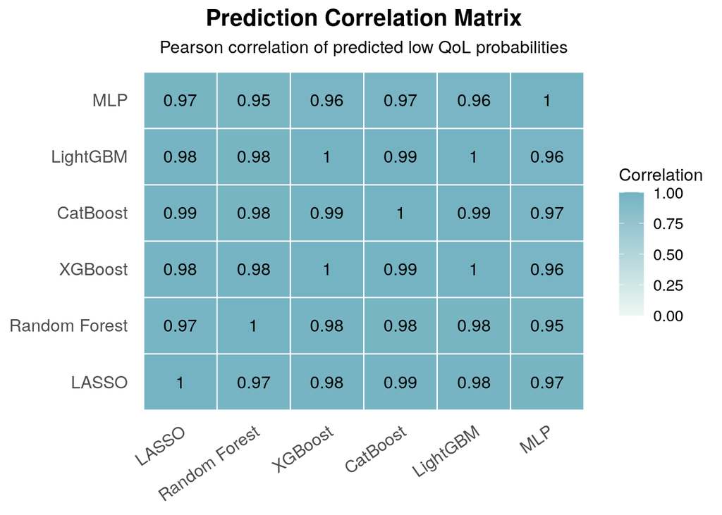

```r
prediction_correlation_heatmap <- prediction_correlation_long %>%
  mutate(
    model_1 = factor(model_1, levels = model_registry$model_short),
    model_2 = factor(model_2, levels = model_registry$model_short)
  ) %>%
  ggplot(aes(x = model_2, y = model_1, fill = correlation)) +
  geom_tile(color = "white", linewidth = 0.4) +
  geom_text(aes(label = round(correlation, 2)), size = 4.2) +
  scale_fill_gradient(
    low = "#EEF8F4",
    high = "#74B3C2",
    limits = c(0, 1)
  ) +
  labs(
    title = "Prediction Correlation Matrix",
    subtitle = "Pearson correlation of predicted low QoL probabilities",
    x = NULL,
    y = NULL,
    fill = "Correlation"
  ) +
  theme_minimal(base_size = 13) +
  theme(
    axis.text.x = element_text(angle = 35, hjust = 1, size = 12),
    axis.text.y = element_text(size = 12),
    legend.title = element_text(size = 12),
    legend.text = element_text(size = 11),
    plot.title = element_text(hjust = 0.5, face = "bold", size = 16),
    plot.subtitle = element_text(hjust = 0.5, size = 12),
    panel.grid = element_blank()
  )

prediction_correlation_heatmap
```

The correlation matrix was used to describe the similarity of predicted Low_QoL probabilities across the six important-feature models. The observed correlation range was interpreted together with the majority-voting results.

# 10 10. Three-model majority voting

The next analysis compares all possible three-model majority-voting combinations among all six important-feature models. With six models, this gives:

```
C(6, 3) = 20 combinations
```

For each three-model combination, the voting rule is:

```
at least 2 of the 3 models predict Low_QoL
=> the ensemble predicts Low_QoL
```

This step does not retrain models. It provides an exploratory descriptive comparison of all three-model majority-voting combinations on the same test set. The ranking is not used to select a final independently validated ensemble.

For majority-voting ensembles, ROC-AUC and PR-AUC are calculated using the proportion of models voting for Low_QoL as the ensemble score.

```r
three_model_combinations <- combn(
  ensemble_model_ids,
  3,
  simplify = FALSE
)

length(three_model_combinations)
```

```
## [1] 20
```

```r
three_model_combinations
```

```
## [[1]]
## [1] "lasso_logistic_selected" "rf_selected"
## [3] "xgb_selected"
##
## [[2]]
## [1] "lasso_logistic_selected" "rf_selected"
## [3] "catboost_selected"
##
## [[3]]
## [1] "lasso_logistic_selected" "rf_selected"
## [3] "lightgbm_selected"
##
## [[4]]
## [1] "lasso_logistic_selected" "rf_selected"
## [3] "mlp_selected"
##
## [[5]]
## [1] "lasso_logistic_selected" "xgb_selected"
## [3] "catboost_selected"
##
## [[6]]
## [1] "lasso_logistic_selected" "xgb_selected"
## [3] "lightgbm_selected"
##
## [[7]]
## [1] "lasso_logistic_selected" "xgb_selected"
## [3] "mlp_selected"
##
## [[8]]
## [1] "lasso_logistic_selected" "catboost_selected"
## [3] "lightgbm_selected"
##
## [[9]]
## [1] "lasso_logistic_selected" "catboost_selected"
## [3] "mlp_selected"
##
## [[10]]
## [1] "lasso_logistic_selected" "lightgbm_selected"
## [3] "mlp_selected"
##
```

[output cut: 14 more lines]

```
##
## [[16]]
## [1] "rf_selected"       "lightgbm_selected" "mlp_selected"
##
## [[17]]
## [1] "xgb_selected"      "catboost_selected" "lightgbm_selected"
##
## [[18]]
## [1] "xgb_selected"      "catboost_selected" "mlp_selected"
##
## [[19]]
## [1] "xgb_selected"      "lightgbm_selected" "mlp_selected"
##
## [[20]]
## [1] "catboost_selected" "lightgbm_selected" "mlp_selected"
```

```r
stopifnot(
  length(three_model_combinations) == choose(length(ensemble_model_ids), 3),
  length(three_model_combinations) == 20L
)
```

```r
make_three_model_majority_predictions <- function(model_ids) {

  combination_registry <- model_registry %>%
    filter(model_id %in% model_ids) %>%
    mutate(model_order = match(model_id, model_ids)) %>%
    arrange(model_order)

  combination_id <- paste(model_ids, collapse = "__")
  combination_label <- paste(combination_registry$model_short, collapse = " + ")

  vote_matrix_i <- class_wide %>%
    select(all_of(model_ids)) %>%
    mutate(
      across(
        everything(),
        ~ as.character(.x) == "Low_QoL"
      )
    ) %>%
    as.matrix()

  model_n_i <- length(model_ids)
  majority_cutoff_i <- ceiling(model_n_i / 2)
  low_qol_vote_count_i <- rowSums(vote_matrix_i)

  tibble(
    idauniq = class_wide$idauniq,
    qol_status = class_wide$qol_status,
    model_id = paste0("three_model_majority__", combination_id),
    model = paste0("Three-model majority: ", combination_label),
    model_combination_id = combination_id,
    model_combination = combination_label,
    low_qol_vote_count = low_qol_vote_count_i,
    model_n = model_n_i,
    majority_cutoff = majority_cutoff_i,
    .pred_Low_QoL = low_qol_vote_count_i / model_n_i,
    .pred_Non_low_QoL = 1 - .pred_Low_QoL,
    .pred_class = factor(
      if_else(low_qol_vote_count_i >= majority_cutoff_i, "Low_QoL", "Non_low_QoL"),
      levels = c("Low_QoL", "Non_low_QoL")
    )
  )
}
```

```r
three_model_majority_predictions <- map_dfr(
  three_model_combinations,
  make_three_model_majority_predictions
)

test_sample_size <- n_distinct(
  selected_model_predictions$idauniq
)

stopifnot(
  nrow(three_model_majority_predictions) == 20L * test_sample_size
)

three_model_majority_predictions %>%
  count(model_id, model)
```

```
## # A tibble: 20 × 3
##    model_id                                                          model     n
##    <chr>                                                             <chr> <int>
##  1 three_model_majority__catboost_selected__lightgbm_selected__mlp_… Thre…  1595
##  2 three_model_majority__lasso_logistic_selected__catboost_selected… Thre…  1595
##  3 three_model_majority__lasso_logistic_selected__catboost_selected… Thre…  1595
##  4 three_model_majority__lasso_logistic_selected__lightgbm_selected… Thre…  1595
##  5 three_model_majority__lasso_logistic_selected__rf_selected__catb… Thre…  1595
##  6 three_model_majority__lasso_logistic_selected__rf_selected__ligh… Thre…  1595
##  7 three_model_majority__lasso_logistic_selected__rf_selected__mlp_… Thre…  1595
##  8 three_model_majority__lasso_logistic_selected__rf_selected__xgb_… Thre…  1595
##  9 three_model_majority__lasso_logistic_selected__xgb_selected__cat… Thre…  1595
## 10 three_model_majority__lasso_logistic_selected__xgb_selected__lig… Thre…  1595
## 11 three_model_majority__lasso_logistic_selected__xgb_selected__mlp… Thre…  1595
## 12 three_model_majority__rf_selected__catboost_selected__lightgbm_s… Thre…  1595
## 13 three_model_majority__rf_selected__catboost_selected__mlp_select… Thre…  1595
## 14 three_model_majority__rf_selected__lightgbm_selected__mlp_select… Thre…  1595
## 15 three_model_majority__rf_selected__xgb_selected__catboost_select… Thre…  1595
## 16 three_model_majority__rf_selected__xgb_selected__lightgbm_select… Thre…  1595
## 17 three_model_majority__rf_selected__xgb_selected__mlp_selected     Thre…  1595
## 18 three_model_majority__xgb_selected__catboost_selected__lightgbm_… Thre…  1595
## 19 three_model_majority__xgb_selected__catboost_selected__mlp_selec… Thre…  1595
## 20 three_model_majority__xgb_selected__lightgbm_selected__mlp_selec… Thre…  1595
```

```r
three_model_majority_results_long <- three_model_majority_predictions %>%
  split(.$model_id) %>%
  map_dfr(
    ~ evaluate_predictions(
      pred_df = .x,
      result_type = "three_model_ensemble",
      threshold = default_threshold
    )
  )

three_model_majority_results_wide <- metrics_to_wide(
  three_model_majority_results_long
) %>%
  mutate(
    model_combination = str_remove(Model, "^Three-model majority: ")
  ) %>%
  select(
    result_type,
    model_id,
    model_combination,
    Model,
    threshold,
    ROC_AUC,
    PR_AUC,
    Accuracy,
    Precision,
    `Sensitivity/Recall`,
    Specificity,
    F1
  )

three_model_majority_results_wide
```

```
## # A tibble: 20 × 12
##    result_type         model_id model_combination Model threshold ROC_AUC PR_AUC
##    <chr>               <chr>    <chr>             <chr>     <dbl>   <dbl>  <dbl>
##  1 three_model_ensemb… three_m… CatBoost + Light… Thre…       0.5   0.812  0.767
##  2 three_model_ensemb… three_m… LASSO + CatBoost… Thre…       0.5   0.808  0.768
##  3 three_model_ensemb… three_m… LASSO + CatBoost… Thre…       0.5   0.809  0.768
##  4 three_model_ensemb… three_m… LASSO + LightGBM… Thre…       0.5   0.811  0.768
##  5 three_model_ensemb… three_m… LASSO + Random F… Thre…       0.5   0.807  0.771
##  6 three_model_ensemb… three_m… LASSO + Random F… Thre…       0.5   0.810  0.772
##  7 three_model_ensemb… three_m… LASSO + Random F… Thre…       0.5   0.808  0.770
##  8 three_model_ensemb… three_m… LASSO + Random F… Thre…       0.5   0.805  0.770
##  9 three_model_ensemb… three_m… LASSO + XGBoost … Thre…       0.5   0.806  0.771
## 10 three_model_ensemb… three_m… LASSO + XGBoost … Thre…       0.5   0.809  0.772
## 11 three_model_ensemb… three_m… LASSO + XGBoost … Thre…       0.5   0.807  0.769
## 12 three_model_ensemb… three_m… Random Forest + … Thre…       0.5   0.808  0.769
## 13 three_model_ensemb… three_m… Random Forest + … Thre…       0.5   0.812  0.771
## 14 three_model_ensemb… three_m… Random Forest + … Thre…       0.5   0.814  0.772
## 15 three_model_ensemb… three_m… Random Forest + … Thre…       0.5   0.803  0.767
## 16 three_model_ensemb… three_m… Random Forest + … Thre…       0.5   0.805  0.767
## 17 three_model_ensemb… three_m… Random Forest + … Thre…       0.5   0.809  0.770
## 18 three_model_ensemb… three_m… XGBoost + CatBoo… Thre…       0.5   0.807  0.769
## 19 three_model_ensemb… three_m… XGBoost + CatBoo… Thre…       0.5   0.811  0.770
## 20 three_model_ensemb… three_m… XGBoost + LightG… Thre…       0.5   0.813  0.771
## # ℹ 5 more variables: Accuracy <dbl>, Precision <dbl>,
## #   `Sensitivity/Recall` <dbl>, Specificity <dbl>, F1 <dbl>
```

```r
three_model_majority_results_ranked <- three_model_majority_results_wide %>%
  arrange(
    desc(F1),
    desc(`Sensitivity/Recall`),
    desc(PR_AUC),
    desc(ROC_AUC)
  )

three_model_majority_results_ranked
```

```
## # A tibble: 20 × 12
##    result_type         model_id model_combination Model threshold ROC_AUC PR_AUC
##    <chr>               <chr>    <chr>             <chr>     <dbl>   <dbl>  <dbl>
##  1 three_model_ensemb… three_m… CatBoost + Light… Thre…       0.5   0.812  0.767
##  2 three_model_ensemb… three_m… LASSO + XGBoost … Thre…       0.5   0.807  0.769
##  3 three_model_ensemb… three_m… LASSO + CatBoost… Thre…       0.5   0.808  0.768
##  4 three_model_ensemb… three_m… LASSO + LightGBM… Thre…       0.5   0.811  0.768
##  5 three_model_ensemb… three_m… Random Forest + … Thre…       0.5   0.803  0.767
##  6 three_model_ensemb… three_m… XGBoost + CatBoo… Thre…       0.5   0.811  0.770
##  7 three_model_ensemb… three_m… Random Forest + … Thre…       0.5   0.808  0.769
##  8 three_model_ensemb… three_m… Random Forest + … Thre…       0.5   0.812  0.771
##  9 three_model_ensemb… three_m… LASSO + CatBoost… Thre…       0.5   0.809  0.768
## 10 three_model_ensemb… three_m… LASSO + Random F… Thre…       0.5   0.808  0.770
## 11 three_model_ensemb… three_m… LASSO + XGBoost … Thre…       0.5   0.806  0.771
## 12 three_model_ensemb… three_m… Random Forest + … Thre…       0.5   0.809  0.770
## 13 three_model_ensemb… three_m… Random Forest + … Thre…       0.5   0.814  0.772
## 14 three_model_ensemb… three_m… LASSO + Random F… Thre…       0.5   0.807  0.771
## 15 three_model_ensemb… three_m… Random Forest + … Thre…       0.5   0.805  0.767
## 16 three_model_ensemb… three_m… XGBoost + CatBoo… Thre…       0.5   0.807  0.769
## 17 three_model_ensemb… three_m… XGBoost + LightG… Thre…       0.5   0.813  0.771
## 18 three_model_ensemb… three_m… LASSO + Random F… Thre…       0.5   0.810  0.772
## 19 three_model_ensemb… three_m… LASSO + Random F… Thre…       0.5   0.805  0.770
## 20 three_model_ensemb… three_m… LASSO + XGBoost … Thre…       0.5   0.809  0.772
## # ℹ 5 more variables: Accuracy <dbl>, Precision <dbl>,
## #   `Sensitivity/Recall` <dbl>, Specificity <dbl>, F1 <dbl>
```

# 11 11. Export results

```r
comparison_excel_file <- file.path(
  output_path,
  "11_three_model_majority_voting_results.xlsx"
)

correlation_plot_file <- file.path(
  picture_path,
  "11_prediction_correlation_heatmap.png"
)

metric_columns <- c(
  "ROC_AUC",
  "PR_AUC",
  "Accuracy",
  "Precision",
  "Sensitivity/Recall",
  "Specificity",
  "F1"
)

single_model_results_export <- single_model_results_wide %>%
  mutate(
    across(
      all_of(metric_columns),
      ~ round(.x, 3)
    )
  )

three_model_results_export <- three_model_majority_results_wide %>%
  mutate(
    across(
      all_of(metric_columns),
      ~ round(.x, 3)
    )
  )

three_model_ranked_export <- three_model_majority_results_ranked %>%
  mutate(
    across(
      all_of(metric_columns),
      ~ round(.x, 3)
    )
  )
```

```r
write_xlsx(
  list(
    three_model_ranked = three_model_ranked_export,
    three_model_results = three_model_results_export,
    single_model_results = single_model_results_export,
    correlation_matrix = prediction_correlation_table,
    correlation_pairs = pairwise_correlation_pairs,
    correlation_summary = correlation_summary,
    high_correlation_pairs = high_correlation_pairs
  ),
  comparison_excel_file
)

ggsave(
  filename = correlation_plot_file,
  plot = prediction_correlation_heatmap,
  width = 9,
  height = 6,
  dpi = 300
)
```

```r
message("11 three-model majority-voting ensemble analysis completed.")
```

```
## 11 three-model majority-voting ensemble analysis completed.
```

```r
message("Read predictions from: ", prediction_file)
```

```
## Read predictions from: /home/rstudio/work/rstudio/M07_Yiwen_upload/data/processed/09_important_model_test_predictions_all6.rds
```

```r
message("Saved three-model comparison Excel: ", comparison_excel_file)
```

```
## Saved three-model comparison Excel: /home/rstudio/work/rstudio/M07_Yiwen_upload/output/11_three_model_majority_voting_results.xlsx
```

```r
message("Saved correlation heatmap: ", correlation_plot_file)
```

```
## Saved correlation heatmap: /home/rstudio/work/rstudio/M07_Yiwen_upload/pictures/11_prediction_correlation_heatmap.png
```